# Flower Classification

In this project, you'll train an image classifier to recognize different species of flowers. We'll be using [this dataset](http://www.robots.ox.ac.uk/~vgg/data/flowers/102/index.html) of 102 flower categories, such as the one below:

[figure not shown]

### The project is broken down into multiple steps:

- Load and preprocess the image dataset
- Load a model with transfer learning
- Train the image classifier on your dataset
- Save and load model checkpoints
- Preprocess user images into Tensors
- Use the trained classifier to predict user image content

### Import Packages

```python
# Imports here
import torch
from torchvision import transforms, datasets, models
from torch import nn, optim
import torch.nn.functional as F
import matplotlib.pyplot as plt
import seaborn as sns
from collections import OrderedDict
from PIL import Image
import numpy as np
```

## Load the data

Here you'll use `torchvision` to load the data ([documentation](http://pytorch.org/docs/0.3.0/torchvision/index.html)). The data should be included alongside this notebook, otherwise you can [download it here](https://s3.amazonaws.com/content.udacity-data.com/nd089/flower_data.tar.gz). The dataset is split into three parts, training, validation, and testing. For the training, you'll want to apply transformations while readin them in. This will help the network generalize leading to better performance. You'll also need to make sure the input data is resized to 224x224 pixels as required by the pre-trained networks.

The validation and testing sets are used to measure the model's performance on data it hasn't seen yet. For this you don't want any scaling or rotation transformations, but you'll need to resize then crop the images to the appropriate size.

The pre-trained networks you'll use were trained on the ImageNet dataset where each color channel was normalized separately. For all three sets you'll need to normalize the means and standard deviations of the images to what the network expects. For the means, it's `[0.485, 0.456, 0.406]` and for the standard deviations `[0.229, 0.224, 0.225]`, calculated from the ImageNet images. These values will shift each color channel to be centered at 0 and range from -1 to 1.

```python
data_dir = 'flowers'
train_dir = data_dir + '/train'
valid_dir = data_dir + '/valid'
test_dir = data_dir + '/test'
```

```python
# Define transforms for the training, validation, and testing sets
train_transforms = transforms.Compose([transforms.RandomRotation(30),
                                       transforms.RandomResizedCrop(224),
                                       transforms.RandomHorizontalFlip(),
                                       transforms.RandomVerticalFlip(),
                                       transforms.ToTensor(),
                                       transforms.Normalize([0.485, 0.456, 0.406],
                                                            [0.229, 0.224, 0.225])])

val_test_transforms = transforms.Compose([transforms.Resize(255),
                                          transforms.CenterCrop(224),
                                          transforms.ToTensor(),
                                          transforms.Normalize([0.485, 0.456, 0.406],
                                                               [0.229, 0.224, 0.225])])

# Load the datasets with ImageFolder
train_data = datasets.ImageFolder(train_dir, transform=train_transforms)
val_data = datasets.ImageFolder(valid_dir, transform=val_test_transforms)
test_data = datasets.ImageFolder(test_dir, transform=val_test_transforms)

# Using the image datasets and the transforms, define the dataloaders
trainloader = torch.utils.data.DataLoader(train_data, batch_size=32, shuffle=True)
val_loader = torch.utils.data.DataLoader(val_data, batch_size=32)
testloader = torch.utils.data.DataLoader(test_data, batch_size=32)
```

### Label mapping

You'll also need to load in a mapping from category label to category name. You can find this in the file `cat_to_name.json`. It's a JSON object which you can read in with the [`json` module](https://docs.python.org/2/library/json.html). This will give you a dictionary mapping the integer encoded categories to the actual names of the flowers.

```python
import json

with open('cat_to_name.json', 'r') as f:
    cat_to_name = json.load(f)
```

# Building and training the classifier

Now that the data is ready, it's time to build and train the classifier. As usual, you should use one of the pretrained models from `torchvision.models` to get the image features. Build and train a new feed-forward classifier using those features.

- Load a [pre-trained network](http://pytorch.org/docs/master/torchvision/models.html)
- Define a new, untrained feed-forward network as a classifier, using ReLU activations and dropout
- Train the classifier layers using backpropagation using the pre-trained network to get the features
- Track the loss and accuracy on the validation set to determine the best hyperparameters

When training make sure you're updating only the weights of the feed-forward network. You should be able to get the validation accuracy above 70% if you build everything right. Make sure to try different hyperparameters (learning rate, units in the classifier, epochs, etc) to find the best model. Save those hyperparameters to use as default values in the next part of the project.

```python
# Import pretrained model and turn off training for layers
model = models.densenet121(pretrained=True)

for param in model.parameters(): # freeze all layers
    param.requires_grad = False
```

```python
# Replace model classifier with new output for 102 flower classes
model.classifier = nn.Sequential(OrderedDict([('fc1', nn.Linear(1024, 512)),
                                              ('relu1', nn.ReLU()),
                                              ('fc2', nn.Linear(512, 256)),
                                              ('relu2', nn.ReLU()),
                                              ('dropout2', nn.Dropout(p=0.4)),
                                              ('fc3', nn.Linear(256,102)),
                                              ('output', nn.LogSoftmax(dim=1))]))
```

```python
criterion = nn.NLLLoss() # define loss function
optimizer = optim.Adam(model.classifier.parameters(), lr=0.001)
```

```python
device = torch.device('cuda' if torch.cuda.is_available() else 'cpu')
print(device)

model.to(device); # move model to correct device memory
```

```
cuda
```

```python
epochs = 5
running_loss = 0

for epoch in range(epochs):
    # Training Loop
    for images, labels in trainloader:
        images, labels = images.to(device), labels.to(device)

        optimizer.zero_grad() # zero out any previous gradients
        log_ps = model.forward(images) # log probabilities
        loss = criterion(log_ps, labels) # calculate loss
        loss.backward() # back prop on model using loss
        optimizer.step() # step in direction of gradient

        running_loss += loss.item() # add loss to current loss count

    # Validation Loop
    else:
        val_loss = 0
        accuracy = 0
        model.eval() # turn off dropout
        with torch.no_grad(): # turn off gradients (faster)
            for images, labels in val_loader:
                images, labels = images.to(device), labels.to(device)

                log_ps = model.forward(images) # log probabilities (model output)
                loss = criterion(log_ps, labels)
                val_loss += loss.item() # add current val loss to total

                ps = torch.exp(log_ps) # calculate actual probabilities
                top_p, top_class = ps.topk(k=1, dim=1) # get top class estimate
                equals = top_class == labels.view(*top_class.shape) # T/F vector of matching labels
                accuracy += torch.mean(equals.type(torch.FloatTensor)).item() # increment accuracy

            print(f'Epoch {epoch+1}/{epochs}... '
                  f'Train Loss: {running_loss/len(trainloader):.3f}... '
                  f'Val Loss: {val_loss/len(val_loader):.3f}... '
                  f'Val Accuracy: {accuracy/len(val_loader):.3f}')
            running_loss = 0 # reset train loss after epoch
            model.train() # turn dropout back on
```

[output not shown]

## Testing your network

It's good practice to test your trained network on test data, images the network has never seen either in training or validation. This will give you a good estimate for the model's performance on completely new images. Run the test images through the network and measure the accuracy, the same way you did validation. You should be able to reach around 70% accuracy on the test set if the model has been trained well.

```python
# Do validation on the test set
test_loss = 0
test_acc = 0
model.eval() # turn off dropout
with torch.no_grad(): # turn off gradients
    for images, labels in testloader:
        images, labels = images.to(device), labels.to(device) # move to device
        log_ps = model.forward(images) # get model output
        loss = criterion(log_ps, labels) # calculate loss
        test_loss += loss.item() # append loss

        ps = torch.exp(log_ps) # convert output to logs
        top_p, top_class = ps.topk(k=1, dim=1) # get predicted class
        equals = top_class == labels.view(*top_class.shape) # number of matching predictions
        test_acc += torch.mean(equals.type(torch.FloatTensor)).item() # append accuracy

    print(f'Test Loss: {test_loss/len(testloader):.3f}... Test Accuracy: {test_acc/len(testloader):.3f}')
    model.train() # turn dropout back on
```

```
Test Loss: 0.692... Test Accuracy: 0.803
```

## Save the checkpoint

Now that your network is trained, save the model so you can load it later for making predictions. You probably want to save other things such as the mapping of classes to indices which you get from one of the image datasets. Remember that you'll want to completely rebuild the model later so you can use it for inference. Make sure to include any information you need in the checkpoint. If you want to load the model and keep training, you'll want to save the number of epochs as well as the optimizer state, `optimizer.state_dict`. You'll likely want to use this trained model in the next part of the project, so best to save it now.

```python
# Save the checkpoint
checkpoint = {'state_dict': model.state_dict(),
              'opt_state': optimizer.state_dict(),
              'classifier': model.classifier,
              'class_to_idx': train_data.class_to_idx # ImageFolder attribute to get labels
              }

torch.save(checkpoint, 'checkpoint.pth')
```

## Loading the checkpoint

At this point it's good to write a function that can load a checkpoint and rebuild the model. That way you can come back to this project and keep working on it without having to retrain the network.

```python
# Write a function that loads a checkpoint and rebuilds the model

def load_checkpoint(filepath):
    checkpoint = torch.load(filepath) # load the saved checkpoint
    model = models.densenet121(pretrained=True); # load pretrained model
    for param in model.parameters(): # turn off gradients
        param.require_grad = False

    device = torch.device('cuda' if torch.cuda.is_available() else 'cpu')
    model.classifier = checkpoint['classifier']
    model.class_to_idx = checkpoint['class_to_idx']
    model.load_state_dict(checkpoint['state_dict'])
    model.to(device)
    return model

model_loaded = load_checkpoint('checkpoint.pth') # load out pretrained model and weights
```

# Inference for classification

Now you'll write a function to use a trained network for inference. That is, you'll pass an image into the network and predict the class of the flower in the image. Write a function called `predict` that takes an image and a model, then returns the top $K$ most likely classes along with the probabilities. First you'll need to handle processing the input image such that it can be used in your network.

## Image Preprocessing

You'll want to use `PIL` to load the image ([documentation](https://pillow.readthedocs.io/en/latest/reference/Image.html)). It's best to write a function that preprocesses the image so it can be used as input for the model. This function should process the images in the same manner used for training.

First, resize the images where the shortest side is 256 pixels, keeping the aspect ratio. This can be done with the [`thumbnail`](http://pillow.readthedocs.io/en/3.1.x/reference/Image.html#PIL.Image.Image.thumbnail) or [`resize`](http://pillow.readthedocs.io/en/3.1.x/reference/Image.html#PIL.Image.Image.thumbnail) methods. Then you'll need to crop out the center 224x224 portion of the image.

Color channels of images are typically encoded as integers 0-255, but the model expected floats 0-1. You'll need to convert the values. It's easiest with a Numpy array, which you can get from a PIL image like so `np_image = np.array(pil_image)`.

As before, the network expects the images to be normalized in a specific way. For the means, it's `[0.485, 0.456, 0.406]` and for the standard deviations `[0.229, 0.224, 0.225]`. You'll want to subtract the means from each color channel, then divide by the standard deviation.

And finally, PyTorch expects the color channel to be the first dimension but it's the third dimension in the PIL image and Numpy array. You can reorder dimensions using [`ndarray.transpose`](https://docs.scipy.org/doc/numpy-1.13.0/reference/generated/numpy.ndarray.transpose.html). The color channel needs to be first and retain the order of the other two dimensions.

```python
def process_image(image):
    '''
    Scales, crops, and normalizes a PIL image for a PyTorch model
    '''
    img = Image.open(image) # open image
    img.thumbnail((256,256), Image.ANTIALIAS) # resize to smallest side 256

    # Center crop
    width, height = img.size
    left = (width - 224)/2
    top = (height - 224)/2
    right = (width + 224)/2
    bottom = (height + 224)/2
    img = img.crop((left, top, right, bottom))
    np_image = np.array(img)

    np_image = np_image/255 # convert to [0,1]
    np_image = (np_image - [0.485, 0.456, 0.406]) / [0.229, 0.224, 0.225] # normalize image to same as model training
    img_final = np_image.transpose(2,0,1) # change channels to match PyTorch

    return img_final
```

To check your work, the function below converts a PyTorch tensor and displays it in the notebook. If your `process_image` function works, running the output through this function should return the original image (except for the cropped out portions).

```python
def imshow(image, ax=None, title=None):
    """Imshow for Tensor."""
    if ax is None:
        fig, ax = plt.subplots()

    # PyTorch tensors assume the color channel is the first dimension
    # but matplotlib assumes is the third dimension
    image = np.asarray(image).transpose((1, 2, 0))

    # Undo preprocessing
    mean = np.array([0.485, 0.456, 0.406])
    std = np.array([0.229, 0.224, 0.225])
    image = std * image + mean

    # Image needs to be clipped between 0 and 1 or it looks like noise when displayed
    image = np.clip(image, 0, 1)

    if title:
        plt.title(title)

    ax.imshow(image)

    return ax
```

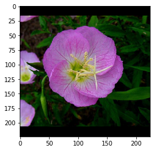

```python
imshow(process_image('flowers/test/1/image_06764.jpg')); # check to see if functions work
```

## Class Prediction

Once you can get images in the correct format, it's time to write a function for making predictions with your model. A common practice is to predict the top 5 or so (usually called top-$K$) most probable classes. You'll want to calculate the class probabilities then find the $K$ largest values.

To get the top $K$ largest values in a tensor use [`x.topk(k)`](http://pytorch.org/docs/master/torch.html#torch.topk). This method returns both the highest `k` probabilities and the indices of those probabilities corresponding to the classes. You need to convert from these indices to the actual class labels using `class_to_idx` which hopefully you added to the model or from an `ImageFolder` you used to load the data (see here). Make sure to invert the dictionary so you get a mapping from index to class as well.

Again, this method should take a path to an image and a model checkpoint, then return the probabilities and classes.

```python
def predict(image_path, model, topk=5):
    ''' Predict the class (or classes) of an image using a trained deep learning model.
    '''
    img = process_image(image_path)
    image = torch.from_numpy(np.expand_dims(img, axis=0)).type(torch.FloatTensor)
    model.eval() # turn off dropout
    with torch.no_grad():
        image = image.to(device)

        log_ps = model.forward(image)
        ps = torch.exp(log_ps)
        top_p, top_class = ps.topk(topk, dim=1)
        model.train()

    idx_to_class = {i:c for c,i in model.class_to_idx.items()} # invert dictionary
    top_p = top_p.reshape(-1).tolist() # convert 2D tensor to list
    top_class = top_class.reshape(-1).tolist() # convert 2D tensor to list
    top_class = [idx_to_class[tc] for tc in top_class] # convert from idx to label

    return top_p, top_class

probs, classes = predict('flowers/test/1/image_06764.jpg', model_loaded)
print(probs)
print(classes)
```

```
[0.9330445528030396, 0.01822921447455883, 0.013423708267509937, 0.009986042976379395, 0.004792872816324234]
['1', '55', '97', '70', '83']
```

## Sanity Checking

Now that you can use a trained model for predictions, check to make sure it makes sense. Even if the testing accuracy is high, it's always good to check that there aren't obvious bugs. Use `matplotlib` to plot the probabilities for the top 5 classes as a bar graph, along with the input image.

You can convert from the class integer encoding to actual flower names with the `cat_to_name.json` file (should have been loaded earlier in the notebook). To show a PyTorch tensor as an image, use the `imshow` function defined above.

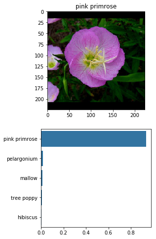

```python
# TODO: Display an image along with the top 5 classes
def sanity_check(image_path, model):
    """
    Plot the picture and top 5 classes for a predicted image.
    """
    probs, classes = predict(image_path, model)
    class_names = [cat_to_name[c] for c in classes]

    plt.figure(figsize=(4,8))
    ax = plt.subplot(2,1,1)
    imshow(process_image(image_path), ax, class_names[0])

    ax = plt.subplot(2,1,2)
    sns.barplot(x=probs, y=class_names, palette=sns.color_palette(n_colors=1)) # use only blue color
    return None

sanity_check('flowers/test/1/image_06764.jpg', model_loaded)
```